# Assessment of the COMPAS Recidivism Algorithm

Patrick Campbell

1/12/2020

### Project Outline

1. Introduction: Data and Problem summary
2. Section 1: Exploratory Data Analysis
3. Section 2: Methodology
4. Section 3: Key Findings, Main takeaways
5. References

### Introduction: Data and Problem Summary

With the advance in machine learning techniques, an increasing number of jurisdictions across the United States are using risk assessment instruments (RAIs) to help judges make bail decisions. These statistical models are often used pre-trial to predict the likelihood that the defendent will commit a crime if released on bail pending their court date.

A major concern with the use of such models is that they might serve to exacerbate bias already present in the criminal justice system by exaggerating or otherwise distorting the meaning of patterns in the data used to train these statistical models. This risk is especially high when RAIs trained on the data of one jurisdiction are later applied to populations of defendents from a completely different jurisdiction. In the case that the new population possesses features not present in the population on which the RAI was trained, we would expect these differences to have a detrimental effect on the RAI’s predictive accuracy.

This is the central concern that motivates the current investigation. For the past several years, courts in Broward County, Florida have been using one of the RAIs in the COMPAS suite to inform pretrial release decisions by predicting the likelihood that a particular defendent will recidivate. In May 2016, investigative journalists from the independents, non-profit newsroom ProPublica conducted an anlysis of one commerical RAI, the COMPAS tool by Northpointe (which stands for Correctional Offender Management Profiling for Alternative Sanctions), and found that “black defendants were far more likely than white defendants to be incorrectly judged to be at a higher risk of recidivism, while white defendants were more likely than black defendants to be incorrectly flagged as low risk (https://www.propublica.org/article/how-we-analyzed-the-compas-recidivism-algorithm).”

The ProPublica team analyzed the COMPAS scores for both “Risk of Recidivism” as well as “Risk of Violent Recidivism.” In this report, I will use the publicly released data from their analysis to attempt to reproduce these two analyses in order to provide independent evidence either in support or in refutation of their findings. An overview of the key tasks covered in this report as well as other supporting resources is provided on the course website at http://www.andrew.cmu.edu/user/achoulde/95791/lectures/lecture05/project_list.html.

#### About the Data

For this study, the ProPublica team looked at more than 10,000 criminal defendants in Broward County, Florida, and compared their predicted recidivism rates with the true rate measured over a two-year period (2013-2014). When the defendants are booked in jail, they are required to respond to a COMPAS questionnaire. Their answers are then fed into the COMPAS software to generate several scores, including predictions of “Risk of Recidivism” and “Risk of Violent Recidivism.” Because Broward County primarily uses these scores to determine whether to release or detain a defendant before his or her trial, the team discarded all scores that were assessed at parole, probation, or other stages in the criminal justice system, leaving them with 11,757 people who were assessed at the pretrial stage (https://www.propublica.org/article/how-we-analyzed-the-compas-recidivism-algorithm).

The team then supplemented this database of COMPAS scores with a profile of each individual’s criminal history, both before and after they were scored. (This public criminal records data was collected from the Broward County Clerk’s Office website through April 1, 2016.) This data included approximately 80,000 criminal records in total. Records were matched using the defendent’s first and last names and date of birth, resulting in an estimated error rate of 3.75 percent (CI: +/- 1.8 percent). Race was assigned using the Broward County Sheriff’s Office’s race classification system, which identifies defendants as black, white, Hispanic, Asian and Native American. In 343 cases, the race was marked as Other. Finally, the team compiled each person’s record of incarceration using jail records received from the Broward County Sheriff’s Office from January 2013 to April 2016. These were supplemented with public incarceration records that were downloaded from the Florida Department of Corrections website. Altogether, there were 2,809 defendants who recidivated within two years in this sample (ibid.).

### Section 1. Exploratory Data Analysis

##### (a) Filter out missing data from regular recidivism data

The original data set contained 7214 records. Following the ProPublica methodology, any row determined not to be useable for the first round of analysis were removed. The reasons cited for removing rows are explained as follows:

“-If the charge date of a defendant’s COMPAS scored crime was not within 30 days from when the person was arrested, we assume that because of data quality reasons, that we do not have the right offense. -We coded the recidivist flag – is_recid – to be -1 if we could not find a compas case at all. -In a similar vein, ordinary traffic offenses – those with a c_charge_degree of ‘O’ – will not result in Jail time are removed (only two of them). -We filtered the underlying data from Broward county to include only those rows representing people who had either recidivated in two years, or had at least two years outside of a correctional facility” (https://github.com/propublica/compas-analysis/blob/master/Compas%20Analysis.ipynb).

After filtering the data, we are left with 6172 records.

##### (b) Use simple summary tables to obtain breakdown of recisivism scores by age_cat, sex, race, and priors_count

```r
# Explore how recidivism differs by race
summary(factor(comp2yr$race))
```

```
## African-American            Asian        Caucasian         Hispanic
##             3175               31             2103              509
##  Native American            Other
##               11              343
```

```r
xtabs(~ race, data = comp2yr)
```

```
## race
## African-American            Asian        Caucasian         Hispanic
##             3175               31             2103              509
##  Native American            Other
##               11              343
```

```r
cat("Black defendants:", round((3175 / 6172 * 100), 2), "%")
```

```
## Black defendants: 51.44 %
```

```r
cat("White defendants:", round((2103 / 6172 * 100), 2), "%")
```

```
## White defendants: 34.07 %
```

```r
cat("Hispanic defendants:", round((509  / 6172 * 100), 2), "%")
```

```
## Hispanic defendants: 8.25 %
```

```r
cat("Asian defendants:", round((31 / 6172 * 100), 2), "%")
```

```
## Asian defendants: 0.5 %
```

```r
cat("Native American defendants:", round((11 / 6172 * 100), 2), "%")
```

```
## Native American defendants: 0.18 %
```

```r
# Explore how recidivism differs by age_category
summary(factor(comp2yr$age_cat))
```

```
##         25 - 45 Greater than 45    Less than 25
##            3532            1293            1347
```

```r
cat("25-45:", round((3532 / 6172 * 100), 2),"%")
```

```
## 25-45: 57.23 %
```

```r
cat("Greater than 45:", round((1293 / 6172 * 100), 2), "%")
```

```
## Greater than 45: 20.95 %
```

```r
cat("Less than 25:", round((1347 / 6172 * 100), 2), "%")
```

```
## Less than 25: 21.82 %
```

```r
# Explore how recidivism differs by race
summary(factor(comp2yr$sex))
```

```
## Female   Male
##   1175   4997
```

```r
cat("Men:", round((4997 / 6172 * 100), 2),"%")
```

```
## Men: 80.96 %
```

```r
cat("Women:", round((1175 / 6172 * 100), 2), "%")
```

```
## Women: 19.04 %
```

```r
# Explore how recidivism differs by multiple categories
# race and sex
xtabs(~ race + sex, data = comp2yr)
```

```
##                   sex
## race               Female Male
##   African-American    549 2626
##   Asian                 2   29
##   Caucasian           482 1621
##   Hispanic             82  427
##   Native American       2    9
##   Other                58  285
```

```r
prop.table(xtabs(~ race + sex, data = comp2yr))
```

```
##                   sex
## race                     Female         Male
##   African-American 0.0889500972 0.4254698639
##   Asian            0.0003240441 0.0046986390
##   Caucasian        0.0780946209 0.2626377187
##   Hispanic         0.0132858069 0.0691834089
##   Native American  0.0003240441 0.0014581983
##   Other            0.0093972780 0.0461762800
```

```r
# race and age
xtabs(~ race + age_cat, data = comp2yr)
```

```
##                   age_cat
## race               25 - 45 Greater than 45 Less than 25
##   African-American    1898             468          809
##   Asian                 14              11            6
##   Caucasian           1128             628          347
##   Hispanic             291             109          109
##   Native American        7               2            2
##   Other                194              75           74
```

```r
prop.table(xtabs(~ race + age_cat, data = comp2yr))
```

```
##                   age_cat
## race                    25 - 45 Greater than 45 Less than 25
##   African-American 0.3075178224    0.0758263124 0.1310758263
##   Asian            0.0022683085    0.0017822424 0.0009721322
##   Caucasian        0.1827608555    0.1017498380 0.0562216461
##   Hispanic         0.0471484122    0.0176604018 0.0176604018
##   Native American  0.0011341542    0.0003240441 0.0003240441
##   Other            0.0314322748    0.0121516526 0.0119896306
```

```r
# sex and age
xtabs(~ sex + age_cat, data = comp2yr)
```

```
##         age_cat
## sex      25 - 45 Greater than 45 Less than 25
##   Female     689             240          246
##   Male      2843            1053         1101
```

```r
prop.table(xtabs(~ sex + age_cat, data = comp2yr))
```

```
##         age_cat
## sex         25 - 45 Greater than 45 Less than 25
##   Female 0.11163318      0.03888529   0.03985742
##   Male   0.46062865      0.17060920   0.17838626
```

```r
# race, sex, and age
xtabs(~ race + sex + age_cat, data = comp2yr)
```

```
## , , age_cat = 25 - 45
##
##                   sex
## race               Female Male
##   African-American    335 1563
##   Asian                 1   13
##   Caucasian           267  861
##   Hispanic             52  239
##   Native American       1    6
##   Other                33  161
##
## , , age_cat = Greater than 45
##
##                   sex
## race               Female Male
##   African-American     69  399
##   Asian                 1   10
##   Caucasian           142  486
##   Hispanic             16   93
##   Native American       1    1
##   Other                11   64
##
## , , age_cat = Less than 25
##
##                   sex
## race               Female Male
##   African-American    145  664
##   Asian                 0    6
##   Caucasian            73  274
##   Hispanic             14   95
##   Native American       0    2
##   Other                14   60
```

```r
prop.table(xtabs(~ race + sex + age_cat, data = comp2yr))
```

```
## , , age_cat = 25 - 45
##
##                   sex
## race                     Female         Male
##   African-American 0.0542773817 0.2532404407
##   Asian            0.0001620220 0.0021062865
##   Caucasian        0.0432598833 0.1395009721
##   Hispanic         0.0084251458 0.0387232664
##   Native American  0.0001620220 0.0009721322
##   Other            0.0053467272 0.0260855476
##
## , , age_cat = Greater than 45
##
##                   sex
## race                     Female         Male
##   African-American 0.0111795204 0.0646467920
##   Asian            0.0001620220 0.0016202203
##   Caucasian        0.0230071290 0.0787427090
##   Hispanic         0.0025923526 0.0150680493
##   Native American  0.0001620220 0.0001620220
##   Other            0.0017822424 0.0103694102
##
## , , age_cat = Less than 25
##
##                   sex
## race                     Female         Male
##   African-American 0.0234931951 0.1075826312
##   Asian            0.0000000000 0.0009721322
##   Caucasian        0.0118276086 0.0443940376
##   Hispanic         0.0022683085 0.0153920933
##   Native American  0.0000000000 0.0003240441
##   Other            0.0022683085 0.0097213221
```

```r
round((3175 / 6172 * 100), 2)
```

```
## [1] 51.44
```

```r
round((2103 / 6172 * 100), 2)
```

```
## [1] 34.07
```

```r
round((509 / 6172 * 100), 2)
```

```
## [1] 8.25
```

```r
round(((3532 / 6172 * 100) - (1347 / 6172 * 100)), 2)
```

```
## [1] 35.4
```

```r
round(((4997 / 6172 * 100) - (1175 / 6172 * 100)), 2)
```

```
## [1] 61.92
```

```r
25.32 - 13.95
```

```
## [1] 11.37
```

A point to note, however, is that the sample sizes vary significantly between each of these categories of defendents, meaning that we should expect higher margins of error in our estimates for those groups with smaller sample sizes.

Next we’ll use the pairs function to examine whether any of the quantitative predictor variables are highly correlated with one another, in order to check for collinearity effects.

##### (c) Use the pairs() function on the set of variables to check if any of the quantitative predictor variables are highly correlated with one another.

```r
# Create quant.vars variable from raw_data1
str(head(raw_data1))
```

```
## Classes 'tbl_df', 'tbl' and 'data.frame':    6 obs. of  53 variables:
##  $ id                     : num  1 3 4 5 6 7
##  $ name                   : chr  "miguel hernandez" "kevon dixon" "ed philo" "marcu brown" ...
##  $ first                  : chr  "miguel" "kevon" "ed" "marcu" ...
##  $ last                   : chr  "hernandez" "dixon" "philo" "brown" ...
##  $ compas_screening_date  : Date, format: "2013-08-14" "2013-01-27" ...
##  $ sex                    : chr  "Male" "Male" "Male" "Male" ...
##  $ dob                    : Date, format: "1947-04-18" "1982-01-22" ...
##  $ age                    : num  69 34 24 23 43 44
##  $ age_cat                : chr  "Greater than 45" "25 - 45" "Less than 25" "Less than 25" ...
##  $ race                   : chr  "Other" "African-American" "African-American" "African-American" ...
##  $ juv_fel_count          : num  0 0 0 0 0 0
##  $ decile_score           : num  1 3 4 8 1 1
##  $ juv_misd_count         : num  0 0 0 1 0 0
##  $ juv_other_count        : num  0 0 1 0 0 0
```

[output cut: 39 more lines]

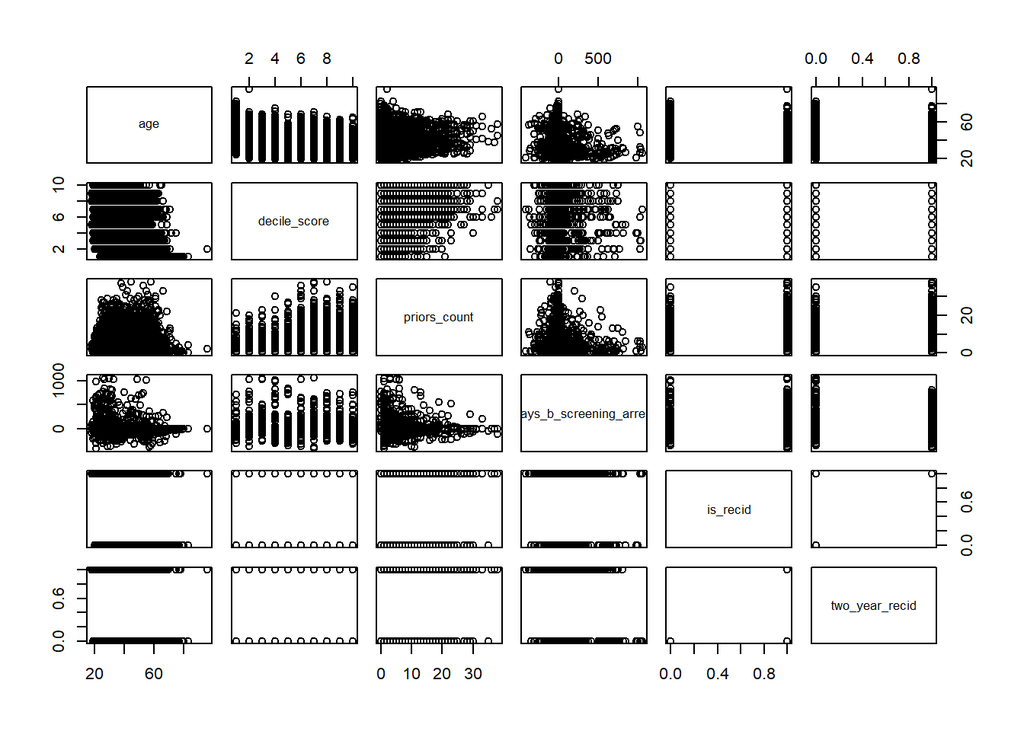

```r
quant.vars1 <- c("age", "decile_score", "priors_count", "days_b_screening_arrest", "is_recid", "two_year_recid")
pairs(raw_data1[,quant.vars1])
```

```r
round(cor(raw_data1[,quant.vars1]), 3)
```

```
##                            age decile_score priors_count
## age                      1.000       -0.388        0.143
## decile_score            -0.388        1.000        0.435
## priors_count             0.143        0.435        1.000
## days_b_screening_arrest     NA           NA           NA
## is_recid                -0.197        0.352        0.278
## two_year_recid          -0.190        0.351        0.275
##                         days_b_screening_arrest is_recid two_year_recid
## age                                          NA   -0.197         -0.190
## decile_score                                 NA    0.352          0.351
## priors_count                                 NA    0.278          0.275
## days_b_screening_arrest                       1       NA             NA
## is_recid                                     NA    1.000          0.941
## two_year_recid                               NA    0.941          1.000
```

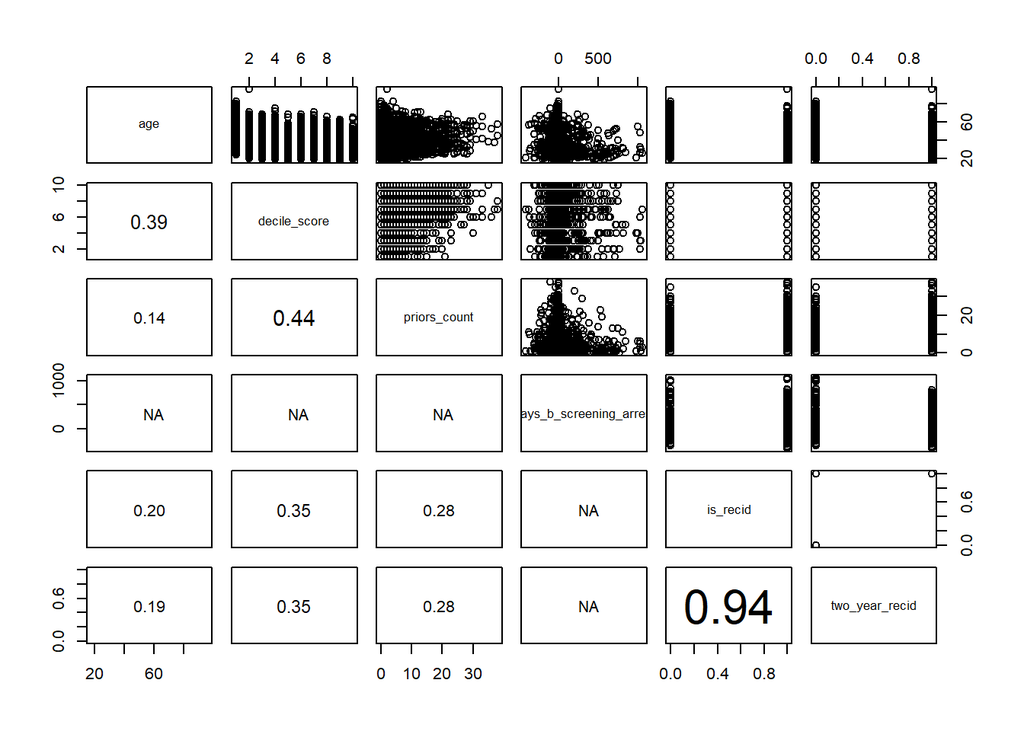

```r
# Create panel.cor function
panel.cor <- function(x, y, digits = 2, prefix = "", cex.cor, ...)
{
    usr <- par("usr"); on.exit(par(usr))
    par(usr = c(0, 1, 0, 1))
    r <- abs(cor(x, y))
    txt <- format(c(r, 0.123456789), digits = digits)[1]
    txt <- paste0(prefix, txt)
    if(missing(cex.cor)) cex.cor <- 0.8/strwidth(txt)
    text(0.5, 0.5, txt, cex = pmax(1, cex.cor * r))
}

# Use panel.cor to display correlations in lower panel
pairs(raw_data1[,quant.vars1], lower.panel = panel.cor)
```

The correlation matrix above only shows strong correlation between the is_recid and two_year_recid predictors, which we’d expect since the one variable is used to calculate the other. Nonetheless, this observation reminds us why it might not be a good idea to include them both as predictors as including them both may tend to exaggerate the influence either one of them is exerting on the outcome, or otherwise mask their individual effect in that relationship. In our primary model, of course, two_year_recid is serving as our outcome variable, so the bigger concern would be using is_recid as a predictor in this model. Most of these observations are obvious once you give them a second’s thought, so Overall, the matrix above is not particulary informative. Next, we move on to evaluate the performance of the COMPAS RAI by analyzing the assignment of decile scores by different race, sex, and age category.

##### (d) Evaluate performance of COMPAS RAI by analyzing assignment of decile scores by race, sex, and age_category

```r
# Evaluate performance of COMPAS RAI by analyzing assignment of decile scores by race and sex
xtabs(~ decile_score + race, data=comp2yr)
```

```
##             race
## decile_score African-American Asian Caucasian Hispanic Native American
##           1               365    15       605      159               0
##           2               346     4       321       89               2
##           3               298     5       238       73               1
##           4               337     0       243       47               0
##           5               323     1       200       39               0
##           6               318     2       160       27               2
##           7               343     1       113       28               2
##           8               301     2        96       14               0
##           9               317     0        77       17               2
##           10              227     1        50       16               2
##             race
## decile_score Other
##           1    142
##           2     60
##           3     32
##           4     39
##           5     19
##           6     20
##           7      9
##           8      7
##           9      7
##           10     8
```

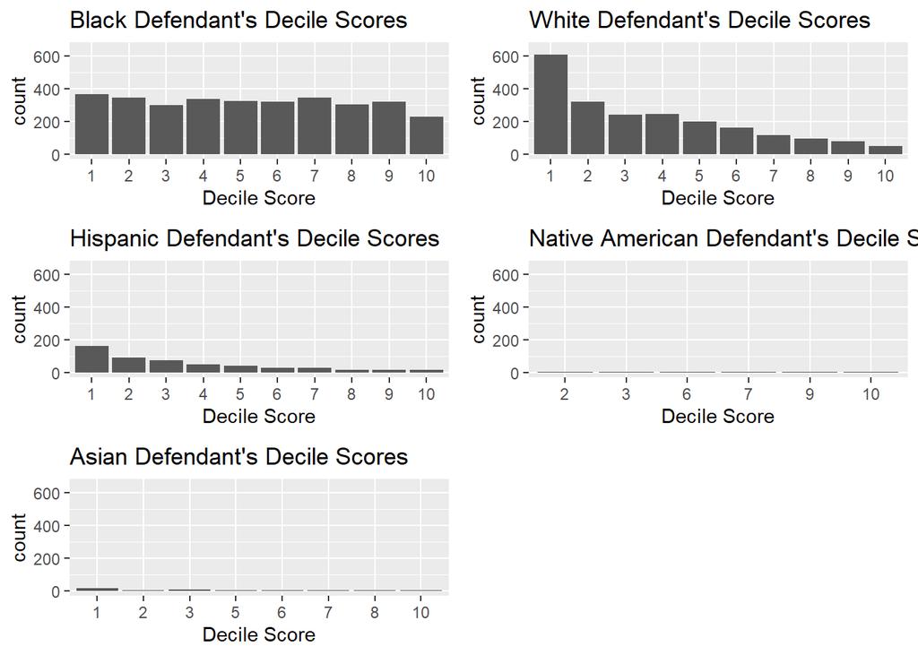

```r
# Plot decile scores by race
pblack <- ggplot(data=filter(comp2yr, race =="African-American"), aes(ordered(decile_score))) +
          geom_bar() + xlab("Decile Score") +
          ylim(0, 650) + ggtitle("Black Defendant's Decile Scores")

pwhite <- ggplot(data=filter(comp2yr, race =="Caucasian"), aes(ordered(decile_score))) +
          geom_bar() + xlab("Decile Score") +
          ylim(0, 650) + ggtitle("White Defendant's Decile Scores")

phispanic <- ggplot(data=filter(comp2yr, race =="Hispanic"), aes(ordered(decile_score))) +
          geom_bar() + xlab("Decile Score") +
          ylim(0, 650) + ggtitle("Hispanic Defendant's Decile Scores")

pnative <- ggplot(data=filter(comp2yr, race =="Native American"), aes(ordered(decile_score))) +
          geom_bar() + xlab("Decile Score") +
          ylim(0, 650) + ggtitle("Native American Defendant's Decile Scores")

pasian <- ggplot(data=filter(comp2yr, race =="Asian"), aes(ordered(decile_score))) +
          geom_bar() + xlab("Decile Score") +
          ylim(0, 650) + ggtitle("Asian Defendant's Decile Scores")

grid.arrange(pblack, pwhite, phispanic, pnative, pasian, ncol = 2)
```

[figure not shown]

```r
# Plot decile scores by sex
pmale <- ggplot(data=filter(comp2yr, sex =="Male"), aes(ordered(decile_score))) +
          geom_bar() + xlab("Decile Score") +
          ylim(0, 650) + ggtitle("Male Defendant's Decile Scores")

pfemale <- ggplot(data=filter(comp2yr, sex =="Female"), aes(ordered(decile_score))) +
          geom_bar() + xlab("Decile Score") +
          ylim(0, 650) + ggtitle("Female Defendant's Decile Scores")

grid.arrange(pmale, pfemale, ncol = 2)
```

[figure not shown]

```r
# Plot decile scores by age_category
punder25 <- ggplot(data=filter(comp2yr, age_cat =="Less than 25"), aes(ordered(decile_score))) +
          geom_bar() + xlab("Decile Score") +
          ylim(0, 650) + ggtitle("Defendant's Decile Scores <25 years")

p25to45 <- ggplot(data=filter(comp2yr, age_cat =="25 - 45"), aes(ordered(decile_score))) +
          geom_bar() + xlab("Decile Score") +
          ylim(0, 650) + ggtitle("Defendant's Decile Scores 25-45 years")

pover45 <- ggplot(data=filter(comp2yr, age_cat =="Greater than 45"), aes(ordered(decile_score))) +
          geom_bar() + xlab("Decile Score") +
          ylim(0, 650) + ggtitle("Defendant's Decile Scores > 45 years")

grid.arrange(punder25, p25to45, pover45, ncol = 2)
```

The histograms above show that the highest two-year recidism scores are assigned to black male defendents between the ages of 25 and 45, which is consistent with what we’d expect given the higher base rates of recidivism among this group. While white defendents are also given relatively high scores by the COMPAS RAI, the distribution of scores is much more skewed toward the low end of the score range compared to black defendents, where the distribution is much more uniform. In other words, white defendents are much more likely to receive “low risk” evaluations by the COMPAS system than are black defendents. Note: A decile score of 1-4 is low (below average), 5-7 is moderate (average), and 8-10 is high (above average) (http://www.northpointeinc.com/files/technical_documents/FieldGuide2_081412.pdf).

Next, I fit a logistic regression model to the regular recidivism data using the two-year recidivism rates as the response and age and the count of prior offenses as the inputs. Two_year_recid is a binary variable. As such, the model below should be intepreted as providing an estimate of the probability of a defendent revidivating as the defendent’s age and number of prior offenses varies. These probability estimates can then be used to classify particular defendents as recidivators or non-recidivators according to various thresholds we might set. For the purposes of this exercise, a cutoff of .5 is used to classify a score as either “Low” or “High,” which is turn is used to predict the defendent who earns that score as either a recidivator or non-recidivator.

The ProPublica team used logistic regression to test whether there was a significant difference in COMPAS scores between races. In order to do this, they first had to change some variables into factors, and run a logistic regression comparing low scores to high scores. We don’t need to repeat their work here, but it’s worth noting that that exercise showed that, indeed, there was a significant difference in COMPAS scores between races. Specfically, they found that black defendents were 45% more likely than white defendants to receive a higher score after correcting for the seriousness of their crime, previous arrests, and future criminal behavior. Perhaps more surprisingly, the COMPAS system was also substantially more likely to give high scores to female defendents (19.4% more likely, to be exact) than to male defendents and 250% more likely to give high scores to defendents under the age of 25 than to middle-aged defendents (https://github.com/propublica/compas-analysis/blob/master/Compas%20Analysis.ipynb).

##### (e) Fit a logistic regression model with two_year_recid as the response and age and priors_count as the inputs.

```r
# Transform variables to factors
comp2yr <- mutate(comp2yr, crime_factor = factor(c_charge_degree)) %>%
      mutate(age_factor = as.factor(age_cat)) %>%
      within(age_factor <- relevel(age_factor, ref = 1)) %>%
      mutate(race_factor = factor(race)) %>%
      within(race_factor <- relevel(race_factor, ref = 3)) %>%
      mutate(gender_factor = factor(sex, labels= c("Female","Male"))) %>%
      within(gender_factor <- relevel(gender_factor, ref = 2)) %>%
      mutate(score_factor = factor(score_text != "Low", labels = c("LowScore","HighScore")))

# create logistic regression model with `two_year_recid` as the response and `age` and `priors_count` as the inputs
log.reg1 <- glm(two_year_recid ~ age + priors_count, family = "binomial", data=comp2yr)

# Use the `summary()` and `kable()` commands to produce a nice looking coefficients table
summary(log.reg1)
```

```
##
## Call:
## glm(formula = two_year_recid ~ age + priors_count, family = "binomial",
##     data = comp2yr)
##
## Deviance Residuals:
##     Min       1Q   Median       3Q      Max
## -2.8348  -1.0352  -0.6119   1.1354   2.5783
##
## Coefficients:
##               Estimate Std. Error z value Pr(>|z|)
## (Intercept)   0.878797   0.089008   9.873   <2e-16 ***
## age          -0.047038   0.002634 -17.859   <2e-16 ***
## priors_count  0.174825   0.007748  22.565   <2e-16 ***
## ---
## Signif. codes:  0 '***' 0.001 '**' 0.01 '*' 0.05 '.' 0.1 ' ' 1
##
## (Dispersion parameter for binomial family taken to be 1)
##
##     Null deviance: 8506.4  on 6171  degrees of freedom
## Residual deviance: 7570.5  on 6169  degrees of freedom
## AIC: 7576.5
##
## Number of Fisher Scoring iterations: 4
```

```r
kable(coef(summary(log.reg1)), digits = c(3, 3, 2, 4))
```

|  | Estimate | Std. Error | z value | Pr(>\|z\|) |
| --- | --- | --- | --- | --- |
| (Intercept) | 0.879 | 0.089 | 9.87 | 0 |
| age | -0.047 | 0.003 | -17.86 | 0 |
| priors_count | 0.175 | 0.008 | 22.57 | 0 |

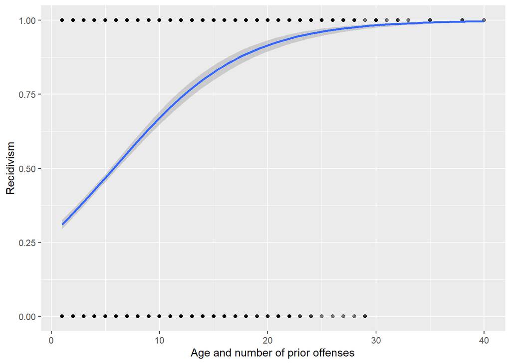

```r
# Plot model with age and priors_count
ggplot(comp2yr, aes(x = as.numeric(age_factor) + priors_count, y = two_year_recid)) +
  geom_point(alpha = .5) +
  stat_smooth(method = "glm", method.args = list(family = "binomial")) +
  ylab("Recidivism") +
  xlab("Age and number of prior offenses")
```

```r
# create logistic regression model with `two_year_recid` as the response and `age`, `priors_count`, 'sex', and 'race' as the inputs
log.reg2 <- glm(two_year_recid ~ age_cat + priors_count + sex + race, family = "binomial", data=comp2yr)

# Use the `summary()` and `kable()` commands to produce a nice looking coefficients table
summary(log.reg2)
```

```
##
## Call:
## glm(formula = two_year_recid ~ age_cat + priors_count + sex +
##     race, family = "binomial", data = comp2yr)
##
## Deviance Residuals:
##     Min       1Q   Median       3Q      Max
## -2.8282  -0.9608  -0.6696   1.1104   2.0261
##
## Coefficients:
##                        Estimate Std. Error z value    Pr(>|z|)
## (Intercept)            -0.95504    0.07800 -12.244     < 2e-16 ***
## age_catGreater than 45 -0.67807    0.07601  -8.921     < 2e-16 ***
## age_catLess than 25     0.75743    0.06859  11.043     < 2e-16 ***
## priors_count            0.16957    0.00803  21.117     < 2e-16 ***
## sexMale                 0.35728    0.07170   4.983 0.000000627 ***
## raceAsian              -0.65185    0.42745  -1.525     0.12726
## raceCaucasian          -0.10519    0.06258  -1.681     0.09279 .
## raceHispanic           -0.28199    0.10521  -2.680     0.00736 **
## raceNative American    -0.38242    0.64699  -0.591     0.55447
## raceOther              -0.25635    0.12505  -2.050     0.04037 *
## ---
## Signif. codes:  0 '***' 0.001 '**' 0.01 '*' 0.05 '.' 0.1 ' ' 1
##
## (Dispersion parameter for binomial family taken to be 1)
##
##     Null deviance: 8506.4  on 6171  degrees of freedom
## Residual deviance: 7590.1  on 6162  degrees of freedom
## AIC: 7610.1
##
## Number of Fisher Scoring iterations: 4
```

```r
kable(coef(summary(log.reg2)), digits = c(3, 3, 2, 4))
```

|  | Estimate | Std. Error | z value | Pr(>\|z\|) |
| --- | --- | --- | --- | --- |
| (Intercept) | -0.955 | 0.078 | -12.24 | 0.0000 |
| age_catGreater than 45 | -0.678 | 0.076 | -8.92 | 0.0000 |
| age_catLess than 25 | 0.757 | 0.069 | 11.04 | 0.0000 |
| priors_count | 0.170 | 0.008 | 21.12 | 0.0000 |
| sexMale | 0.357 | 0.072 | 4.98 | 0.0000 |
| raceAsian | -0.652 | 0.427 | -1.52 | 0.1273 |
| raceCaucasian | -0.105 | 0.063 | -1.68 | 0.0928 |
| raceHispanic | -0.282 | 0.105 | -2.68 | 0.0074 |
| raceNative American | -0.382 | 0.647 | -0.59 | 0.5545 |
| raceOther | -0.256 | 0.125 | -2.05 | 0.0404 |

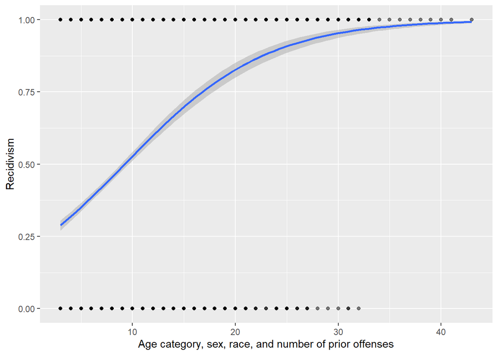

```r
# Plot model with all inputs
ggplot(comp2yr, aes(x = as.numeric(age_factor) + priors_count + as.numeric(gender_factor) + as.numeric(race_factor), y = two_year_recid)) +
  geom_point(alpha = .5) +
  stat_smooth(method = "glm", method.args = list(family = "binomial")) +
  ylab("Recidivism") +
  xlab("Age category, sex, race, and number of prior offenses")
```

```r
# Identify the statistically significant predictors
sig.coef2 <- summary(log.reg2)$coef[summary(log.reg2)$coef[,4] <= .05, 4]
names(sig.coef2)
```

```
## [1] "(Intercept)"            "age_catGreater than 45"
## [3] "age_catLess than 25"    "priors_count"
## [5] "sexMale"                "raceHispanic"
## [7] "raceOther"
```

In the first model, both age and priors_count are statistically significant at the p < 0.05 level. In the second model, the statistically significant predictors are (Intercept), age_catGreater than 45, age_catLess than 25, priors_count, sexMale, raceHispanic, raceOther.

The coefficients derived from the logistic regression model indicate the change in the expected log odds relative to a one unit change in each predictor, X1, holding all other predictors constant (see http://sphweb.bumc.bu.edu/otlt/MPH-Modules/BS/BS704_Multivariable/BS704_Multivariable8.html). The intercept, in the case of the second model, represents a hypothetical black female defendent between the ages of 25 and 45. Relative to this baseline, being male increases the expected log odds of recidivating by 35.7 percentage points holding all other predictors constant. In contrast, being Hispanic reduces the expected log odds of recidivating by 28.2 percentage points holding all other predictors constant. Similarly, being in the greater than 45 age group reduces the expected log odds of recidivating by a surprising 67.8 percentage points holding all other predictors constant. Finally, having one additional prior offense on your record increases the expected log odds of recidivating by 17 percentage points holding all other predictors constant.

##### (h) Apply a Random Forest model

```r
# Split into Train and Validation sets
# Training Set : Validation Set = 70 : 30 (random)
set.seed(999)
train <- sample(nrow(comp2yr), 0.7*nrow(comp2yr), replace = FALSE)
TrainSet <- comp2yr[train,]
ValidSet <- comp2yr[-train,]
summary(TrainSet)
```

```
##       age        c_charge_degree        race             age_cat
##  Min.   :18.00   Length:4320        Length:4320        Length:4320
##  1st Qu.:25.00   Class :character   Class :character   Class :character
##  Median :31.00   Mode  :character   Mode  :character   Mode  :character
##  Mean   :34.51
##  3rd Qu.:42.00
##  Max.   :96.00
##   score_text            sex             priors_count
##  Length:4320        Length:4320        Min.   : 0.000
##  Class :character   Class :character   1st Qu.: 0.000
##  Mode  :character   Mode  :character   Median : 1.000
##                                        Mean   : 3.272
##                                        3rd Qu.: 4.000
##                                        Max.   :37.000
##  days_b_screening_arrest  decile_score      is_recid      two_year_recid
##  Min.   :-30.000         Min.   : 1.00   Min.   :0.0000   Min.   :0.0000
##  1st Qu.: -1.000         1st Qu.: 2.00   1st Qu.:0.0000   1st Qu.:0.0000
##  Median : -1.000         Median : 4.00   Median :0.0000   Median :0.0000
##  Mean   : -1.736         Mean   : 4.42   Mean   :0.4829   Mean   :0.4544
##  3rd Qu.: -1.000         3rd Qu.: 7.00   3rd Qu.:1.0000   3rd Qu.:1.0000
##  Max.   : 30.000         Max.   :10.00   Max.   :1.0000   Max.   :1.0000
##    c_jail_in                     c_jail_out                  crime_factor
##  Min.   :2013-01-01 01:31:55   Min.   :2013-01-02 01:12:01   F:2777
##  1st Qu.:2013-04-05 06:44:47   1st Qu.:2013-04-18 05:55:24   M:1543
##  Median :2013-09-10 10:00:13   Median :2013-09-26 04:16:44
##  Mean   :2013-09-19 21:23:18   Mean   :2013-10-04 12:52:04
##  3rd Qu.:2014-01-24 05:44:48   3rd Qu.:2014-02-04 01:15:08
##  Max.   :2015-01-10 02:50:22   Max.   :2015-10-13 07:10:00
##            age_factor             race_factor   gender_factor
##  25 - 45        :2461   Caucasian       :1460   Male  :3513
##  Greater than 45: 908   African-American:2224   Female: 807
##  Less than 25   : 951   Asian           :  20
##                         Hispanic        : 358
##                         Native American :  11
##                         Other           : 247
##     score_factor
##  LowScore :2390
##  HighScore:1930
##
##
##
##
```

```r
str(TrainSet)
```

```
## Classes 'tbl_df', 'tbl' and 'data.frame':    4320 obs. of  18 variables:
##  $ age                    : num  59 23 56 25 25 20 34 32 20 28 ...
##  $ c_charge_degree        : chr  "F" "F" "F" "F" ...
##  $ race                   : chr  "Caucasian" "African-American" "Caucasian" "Caucasian" ...
##  $ age_cat                : chr  "Greater than 45" "Less than 25" "Greater than 45" "25 - 45" ...
##  $ score_text             : chr  "Low" "Medium" "Low" "Medium" ...
##  $ sex                    : chr  "Male" "Male" "Male" "Female" ...
##  $ priors_count           : num  2 1 2 0 2 0 4 2 1 9 ...
##  $ days_b_screening_arrest: num  0 -1 -4 0 -1 -1 -1 -1 0 -8 ...
##  $ decile_score           : num  1 6 4 5 8 6 2 2 5 8 ...
##  $ is_recid               : num  0 1 0 0 1 1 0 0 1 1 ...
##  $ two_year_recid         : num  0 1 0 0 1 1 0 0 1 1 ...
##  $ c_jail_in              : POSIXct, format: "2013-03-21 12:43:41" "2013-04-17 08:54:18" ...
##  $ c_jail_out             : POSIXct, format: "2013-04-03 07:34:10" "2013-04-21 04:37:02" ...
##  $ crime_factor           : Factor w/ 2 levels "F","M": 1 1 1 1 1 2 2 1 2 1 ...
##  $ age_factor             : Factor w/ 3 levels "25 - 45","Greater than 45",..: 2 3 2 1 1 3 1 1 3 1 ...
##  $ race_factor            : Factor w/ 6 levels "Caucasian","African-American",..: 1 2 1 1 2 6 2 1 2 1 ...
##  $ gender_factor          : Factor w/ 2 levels "Male","Female": 1 1 1 2 2 1 1 1 1 1 ...
##  $ score_factor           : Factor w/ 2 levels "LowScore","HighScore": 1 2 1 2 2 2 1 1 2 2 ...
```

```r
summary(ValidSet)
```

```
##       age        c_charge_degree        race             age_cat
##  Min.   :19.00   Length:1852        Length:1852        Length:1852
##  1st Qu.:25.00   Class :character   Class :character   Class :character
##  Median :31.00   Mode  :character   Mode  :character   Mode  :character
##  Mean   :34.59
##  3rd Qu.:42.00
##  Max.   :75.00
##   score_text            sex             priors_count
##  Length:1852        Length:1852        Min.   : 0.000
##  Class :character   Class :character   1st Qu.: 0.000
##  Mode  :character   Mode  :character   Median : 1.000
##                                        Mean   : 3.187
##                                        3rd Qu.: 4.000
##                                        Max.   :38.000
##  days_b_screening_arrest  decile_score       is_recid
##  Min.   :-30.000         Min.   : 1.000   Min.   :0.0000
##  1st Qu.: -1.000         1st Qu.: 2.000   1st Qu.:0.0000
##  Median : -1.000         Median : 4.000   Median :0.0000
##  Mean   : -1.749         Mean   : 4.414   Mean   :0.4881
##  3rd Qu.: -1.000         3rd Qu.: 7.000   3rd Qu.:1.0000
##  Max.   : 30.000         Max.   :10.000   Max.   :1.0000
##  two_year_recid     c_jail_in
##  Min.   :0.0000   Min.   :2013-01-01 03:16:15
##  1st Qu.:0.0000   1st Qu.:2013-03-29 07:11:49
##  Median :0.0000   Median :2013-09-16 04:48:50
##  Mean   :0.4568   Mean   :2013-09-20 03:52:30
##  3rd Qu.:1.0000   3rd Qu.:2014-01-25 04:46:56
##  Max.   :1.0000   Max.   :2014-12-29 01:25:41
##    c_jail_out                  crime_factor           age_factor
##  Min.   :2013-01-02 01:39:04   F:1193       25 - 45        :1071
##  1st Qu.:2013-04-15 09:12:53   M: 659       Greater than 45: 385
##  Median :2013-09-27 09:31:14                Less than 25   : 396
##  Mean   :2013-10-06 08:38:39
##  3rd Qu.:2014-02-04 07:51:46
##  Max.   :2015-10-03 06:50:34
##            race_factor  gender_factor    score_factor
##  Caucasian       :643   Male  :1484   LowScore :1031
##  African-American:951   Female: 368   HighScore: 821
##  Asian           : 11
##  Hispanic        :151
##  Native American :  0
##  Other           : 96
```

```r
# Create a Random Forest model with default parameters
RandForest1 <- randomForest(as.factor(two_year_recid) ~ age + priors_count, data = TrainSet, importance = TRUE) # just use two predictors (age and priors.count)
RandForest1
```

```
##
## Call:
##  randomForest(formula = as.factor(two_year_recid) ~ age + priors_count,      data = TrainSet, importance = TRUE)
##                Type of random forest: classification
##                      Number of trees: 500
## No. of variables tried at each split: 1
##
##         OOB estimate of  error rate: 33.17%
## Confusion matrix:
##      0    1 class.error
## 0 1771  586   0.2486211
## 1  847 1116   0.4314824
```

```r
# Fine tuning parameters of Random Forest model
RandForest2 <- randomForest(as.factor(two_year_recid) ~ age + priors_count, data = TrainSet, ntree = 500, mtry = 1, importance = TRUE)
RandForest2
```

```
##
## Call:
##  randomForest(formula = as.factor(two_year_recid) ~ age + priors_count,      data = TrainSet, ntree = 500, mtry = 1, importance = TRUE)
##                Type of random forest: classification
##                      Number of trees: 500
## No. of variables tried at each split: 1
##
##         OOB estimate of  error rate: 33.43%
## Confusion matrix:
##      0    1 class.error
## 0 1795  562   0.2384387
## 1  882 1081   0.4493123
```

```r
# add additional predictors
RandForest3 <- randomForest(as.factor(two_year_recid) ~ age_factor + crime_factor + priors_count + gender_factor + race_factor, data = TrainSet, ntree = 500, mtry = 3, importance = TRUE)
RandForest3
```

```
##
## Call:
##  randomForest(formula = as.factor(two_year_recid) ~ age_factor +      crime_factor + priors_count + gender_factor + race_factor,      data = TrainSet, ntree = 500, mtry = 3, importance = TRUE)
##                Type of random forest: classification
##                      Number of trees: 500
## No. of variables tried at each split: 3
##
##         OOB estimate of  error rate: 33.94%
## Confusion matrix:
##      0    1 class.error
## 0 1789  568   0.2409843
## 1  898 1065   0.4574631
```

```r
# Predicting on train set
predTrain <- predict(RandForest2, TrainSet, type = "class")

# Checking classification accuracy
table(predTrain, TrainSet$two_year_recid)
```

```
##
## predTrain    0    1
##         0 1877  753
##         1  480 1210
```

```r
# Predicting on Validation set
predValid <- predict(RandForest2, ValidSet, type = "class")

# Checking classification accuracy
mean(predValid == ValidSet$two_year_recid)
```

```
## [1] 0.6798056
```

```r
table(predValid,ValidSet$two_year_recid)
```

```
##
## predValid   0   1
##         0 768 355
##         1 238 491
```

```r
# To check important variables
importance(RandForest2)
```

```
##                     0        1 MeanDecreaseAccuracy MeanDecreaseGini
## age          35.54546  51.0440             59.07794         220.3444
## priors_count 93.22858 124.2813            151.37475         331.4301
```

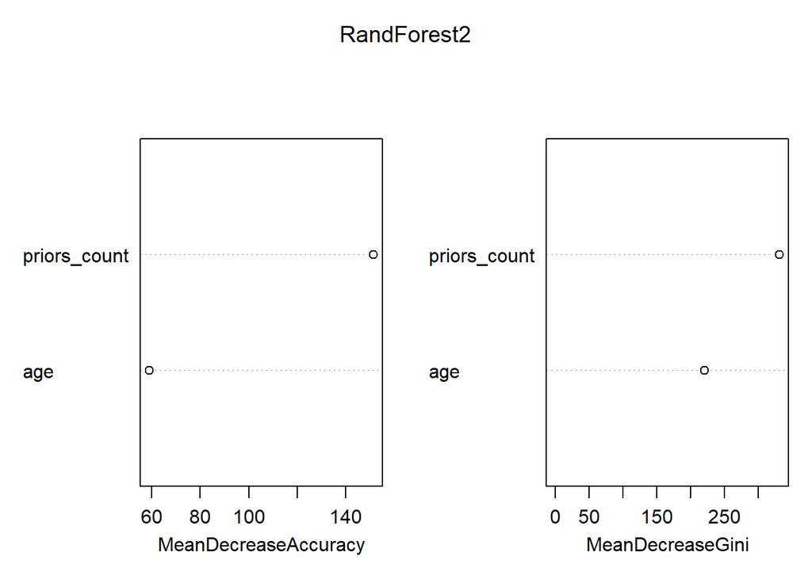

```r
varImpPlot(RandForest2)
```

```r
# Update Random tree model to use optimal value for mtry
RandForest4 <- randomForest(as.factor(two_year_recid) ~ age_factor + crime_factor + priors_count + gender_factor + race_factor, data = TrainSet, ntree = 500, mtry = 6, importance = TRUE)
RandForest4
```

```
##
## Call:
##  randomForest(formula = as.factor(two_year_recid) ~ age_factor +      crime_factor + priors_count + gender_factor + race_factor,      data = TrainSet, ntree = 500, mtry = 6, importance = TRUE)
##                Type of random forest: classification
##                      Number of trees: 500
## No. of variables tried at each split: 5
##
##         OOB estimate of  error rate: 35.32%
## Confusion matrix:
##      0    1 class.error
## 0 1768  589   0.2498939
## 1  937 1026   0.4773306
```

### Section 2. Methodology

My general approach in executing this project was to follow method outlined here by the ProPublica team: https://github.com/propublica/compas-analysis/blob/master/Compas%20Analysis.ipynb. I adapted their methodology to better suit the parameters of this project, resulting in the following list of actions:

(Due to time restrictions, I was unable to complete all of the steps included in the plan below. I include them here to indicate what my strategy would have been had I more time to complete the project, or to otherwise indicate my level of understanding of the process as of the moment this assignment was submitted.)

1. Do descriptive analysis of violent recidivism outcomes and inputs
2. Fit a logistic regression model with just two variables (to make sure model works)
3. Add additional variables to your regression model
4. Fit a lasso to your expanded regression model and identify best subset of variables
5. Revise regression model according to results of lasso
6. Fit a random forest model with just two variables (to make sure model works)
7. Add additional variables to your random forest model
8. Fit a lasso to your expanded random forest model and identify best subset of variables (?)
9. Revise random forest model according to results of lasso
10. Apply the same models to the violent recidivism data set (preferably before you select a best performing model, but can save time by doing the selection before applying it to the other data set, and probably the result will be roughly the same)
11. Calculate decile scores for each of your models
12. Evaluate performance of two models and compare; determine which is superior
13. Compare the performance of your chosen model (using the calculated decile scores) with that of the COMPAS RAI.
14. Use logistic regression to check for bias in your models, just like the ProPublica team did in section (e).
15. Draw conclusions and discuss.

##### (a) Overview and Evaluation of Data Mining Methods Used

**Descriptive Methods** In conducting this analysis, I used the following data mining methods. First, I ran descriptive statistics on the raw data for both general recidivism as well as violent recidivism to see how the outcome of interest (two_year_recid) is associated with different values of the race, sex, and age of the individual. I used simple summary tables to obtain a breakdown of recisivism scores by age_cat, sex, race, and priors_count. Next, I evaluated the performance of the COMPAS RAI by analyzing its assignment of decile scores by race, sex, and age_category. Finally, I ran tests for colinearity (specifically, the pairs function) in order to identify redunandant variables that might be masking the effects of the predictors of interest.

**Predictive Methods** Second, I fit a logistic regression model to the relationship between the outcome and several variables I expected to be most strongly associated with the outcome, namely, race, sex, age category, and number of prior offenses. After building the model, I examined the summary table to determine which predictors were statistically significant at the p < .05 level. I used the results of this tests to eliminate any variable that was redundant or not statistically significant from my final model (i.e., my Broward County-specific RAI).

Next, I used the BIC method to select the best model. I chose to use the BIC method rather than the AIC method because I preferred a simpler model. Simple models have more bias than more complex models, but less variability, meaning they tend to have less error when applied to the test data set.

Third, I fit a random forest model to the relationship between the outcome and the same variables I used in my first model (logistic regression). I did this to see if one model did a significantly better job at modeling the relationship.

In both the logistic and random forest models, I began by building the simplest version of the respective models to ensure that the they were functional before attempting to add additional variables. I did this as a means of troubleshooting each model before it became too complex to be able to quickly diagnose the cause of any subsequent malfunction. Once I had each model functioning properly, I proceeded to add variables one by one until I had I had included all the variables I judged to be most significant. In the case of the logistic regression model, I then used the lasso method to select the best subset of variables from those that I had included. The resulting model became my final model for this exercise.

Fourth, I compared the performance of the two final models (the logistic regression and random forest models) by calculating the cross validation error. I used confusion matrices to display the proportion of accurate to erroneous predictions relative to the actual recidivism rates. I did this for both regular as well as violent recidivism.

Fifth, I generated decile scores for my final model by calculating what proportion of defendents in the sample fell within each bin (get each score). Next, I created proportions tables to display these proportions and identified cut points to model probabilities (specifically, I used 9 cut points in order to produce 10 bins of equal size to the COMPAS proportions). For these steps, I used the CUMSUM, quantile, and prop table functions.

### Section 3: Key Findings and Takeaways

*Instructions:* Be sure to clearly answer, in context-appropriate language, each and every question stated in your Project’s description file. Provide Figures, Tables, nicely formatted model output, and accompanying discussion of your main findings.

In this section, I address the following questions:

1. The COMPAS tool was not developed on the Broward County population. Going forward, the County is considering developing their own RAI to replace COMPAS. Using the available data, construct an RAI for predicting two-year recidivism. Evaluate the predictive performance of your model. What are the most important predictors of recidivism?
2. Construct an RAI for predicting violent recidivism. Evaluate the predictive performance of your model. What are the most important predictors of violent recidivism? How do they compare to the important predictors of general recidivism?
3. Are your RAIs from (1) and (2) equally predictive across race/ethnicity groups? How about across age and sex groups?
4. Compare your RAIs to the COMPAS RAI. Do your RAIs perform better or worse than COMPAS? Do your RAIs produce similar classifications to COMPAS? Can you identify any systematic differences between your classifications and those of COMPAS?

#### *(Q1)* The COMPAS tool was not developed on the Broward County population. Going forward, the County is considering developing their own RAI to replace COMPAS. Using the available data, construct an RAI for predicting two-year recidivism. Evaluate the predictive performance of your model. What are the most important predictors of recidivism?

##### (a) construct an RAI for predicting two-year recidivism.

```r
# Use the `summary()` and `kable()` commands to produce a nice looking coefficients table
summary(log.reg2)
```

```
##
## Call:
## glm(formula = two_year_recid ~ age_cat + priors_count + sex +
##     race, family = "binomial", data = comp2yr)
##
## Deviance Residuals:
##     Min       1Q   Median       3Q      Max
## -2.8282  -0.9608  -0.6696   1.1104   2.0261
##
## Coefficients:
##                        Estimate Std. Error z value    Pr(>|z|)
## (Intercept)            -0.95504    0.07800 -12.244     < 2e-16 ***
## age_catGreater than 45 -0.67807    0.07601  -8.921     < 2e-16 ***
## age_catLess than 25     0.75743    0.06859  11.043     < 2e-16 ***
## priors_count            0.16957    0.00803  21.117     < 2e-16 ***
## sexMale                 0.35728    0.07170   4.983 0.000000627 ***
## raceAsian              -0.65185    0.42745  -1.525     0.12726
## raceCaucasian          -0.10519    0.06258  -1.681     0.09279 .
## raceHispanic           -0.28199    0.10521  -2.680     0.00736 **
## raceNative American    -0.38242    0.64699  -0.591     0.55447
## raceOther              -0.25635    0.12505  -2.050     0.04037 *
## ---
## Signif. codes:  0 '***' 0.001 '**' 0.01 '*' 0.05 '.' 0.1 ' ' 1
##
## (Dispersion parameter for binomial family taken to be 1)
##
##     Null deviance: 8506.4  on 6171  degrees of freedom
## Residual deviance: 7590.1  on 6162  degrees of freedom
## AIC: 7610.1
##
## Number of Fisher Scoring iterations: 4
```

```r
kable(coef(summary(log.reg2)), digits = c(3, 3, 2, 4))
```

|  | Estimate | Std. Error | z value | Pr(>\|z\|) |
| --- | --- | --- | --- | --- |
| (Intercept) | -0.955 | 0.078 | -12.24 | 0.0000 |
| age_catGreater than 45 | -0.678 | 0.076 | -8.92 | 0.0000 |
| age_catLess than 25 | 0.757 | 0.069 | 11.04 | 0.0000 |
| priors_count | 0.170 | 0.008 | 21.12 | 0.0000 |
| sexMale | 0.357 | 0.072 | 4.98 | 0.0000 |
| raceAsian | -0.652 | 0.427 | -1.52 | 0.1273 |
| raceCaucasian | -0.105 | 0.063 | -1.68 | 0.0928 |
| raceHispanic | -0.282 | 0.105 | -2.68 | 0.0074 |
| raceNative American | -0.382 | 0.647 | -0.59 | 0.5545 |
| raceOther | -0.256 | 0.125 | -2.05 | 0.0404 |

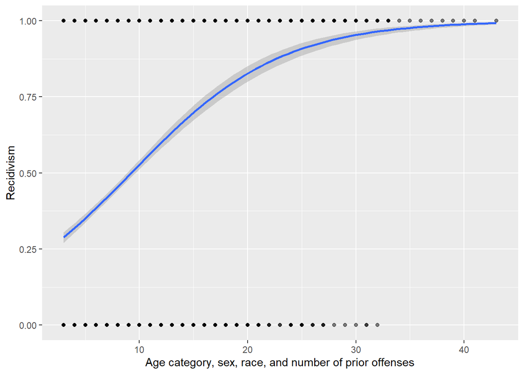

```r
# Plot model with all inputs
ggplot(comp2yr, aes(x = as.numeric(age_factor) + priors_count + as.numeric(gender_factor) + as.numeric(race_factor), y = two_year_recid)) +
  geom_point(alpha = .5) +
  stat_smooth(method = "glm", method.args = list(family = "binomial")) +
  ylab("Recidivism") +
  xlab("Age category, sex, race, and number of prior offenses")
```

##### (c) Determine the most important predictors. Use the glm command to fit a linear regression of two_year_recid on all the other variables in the comp2yr data set. Print the names of the predictors whose coefficient estimates are statistically significant at the 0.05 level.

```r
# Determine the most important predictors of recidivism
# Print the names of the predictors whose coefficient estimates are statistically significant at the 0.05 level
names(sig.coef2)
```

```
## [1] "(Intercept)"            "age_catGreater than 45"
## [3] "age_catLess than 25"    "priors_count"
## [5] "sexMale"                "raceHispanic"
## [7] "raceOther"
```

#### *(Q2)* Construct an RAI for predicting violent recidivism. Evaluate the predictive performance of your model. What are the most important predictors of violent recidivism? How do they compare to the important predictors of general recidivism?

##### (a) Construct an RAI for predicting violent recidivism

```r
# Transform variables to factors
compvio <- mutate(compvio, crime_factor = factor(c_charge_degree)) %>%
      mutate(age_factor = as.factor(age_cat)) %>%
      within(age_factor <- relevel(age_factor, ref = 1)) %>%
      mutate(race_factor = factor(race)) %>%
      within(race_factor <- relevel(race_factor, ref = 3)) %>%
      mutate(gender_factor = factor(sex, labels= c("Female","Male"))) %>%
      within(gender_factor <- relevel(gender_factor, ref = 2)) %>%
      mutate(score_factor = factor(score_text != "Low", labels = c("LowScore","HighScore")))

# create logistic regression model with `two_year_recid` as the response and `age` and `priors_count` as the inputs
log.reg3 <- glm(two_year_recid ~ age + priors_count, family = "binomial", data=compvio)

# Use the `summary()` and `kable()` commands to produce a nice looking coefficients table
summary(log.reg3)
```

```
##
## Call:
## glm(formula = two_year_recid ~ age + priors_count, family = "binomial",
##     data = compvio)
##
## Deviance Residuals:
##     Min       1Q   Median       3Q      Max
## -2.1795  -0.6240  -0.4855  -0.2845   3.0211
##
## Coefficients:
##               Estimate Std. Error z value Pr(>|z|)
## (Intercept)  -0.182416   0.157711  -1.157    0.247
## age          -0.058909   0.005009 -11.762   <2e-16 ***
## priors_count  0.165290   0.010278  16.082   <2e-16 ***
## ---
## Signif. codes:  0 '***' 0.001 '**' 0.01 '*' 0.05 '.' 0.1 ' ' 1
##
## (Dispersion parameter for binomial family taken to be 1)
##
##     Null deviance: 3562.2  on 4014  degrees of freedom
## Residual deviance: 3167.4  on 4012  degrees of freedom
## AIC: 3173.4
##
## Number of Fisher Scoring iterations: 5
```

```r
kable(coef(summary(log.reg3)), digits = c(3, 3, 2, 4))
```

|  | Estimate | Std. Error | z value | Pr(>\|z\|) |
| --- | --- | --- | --- | --- |
| (Intercept) | -0.182 | 0.158 | -1.16 | 0.2474 |
| age | -0.059 | 0.005 | -11.76 | 0.0000 |
| priors_count | 0.165 | 0.010 | 16.08 | 0.0000 |

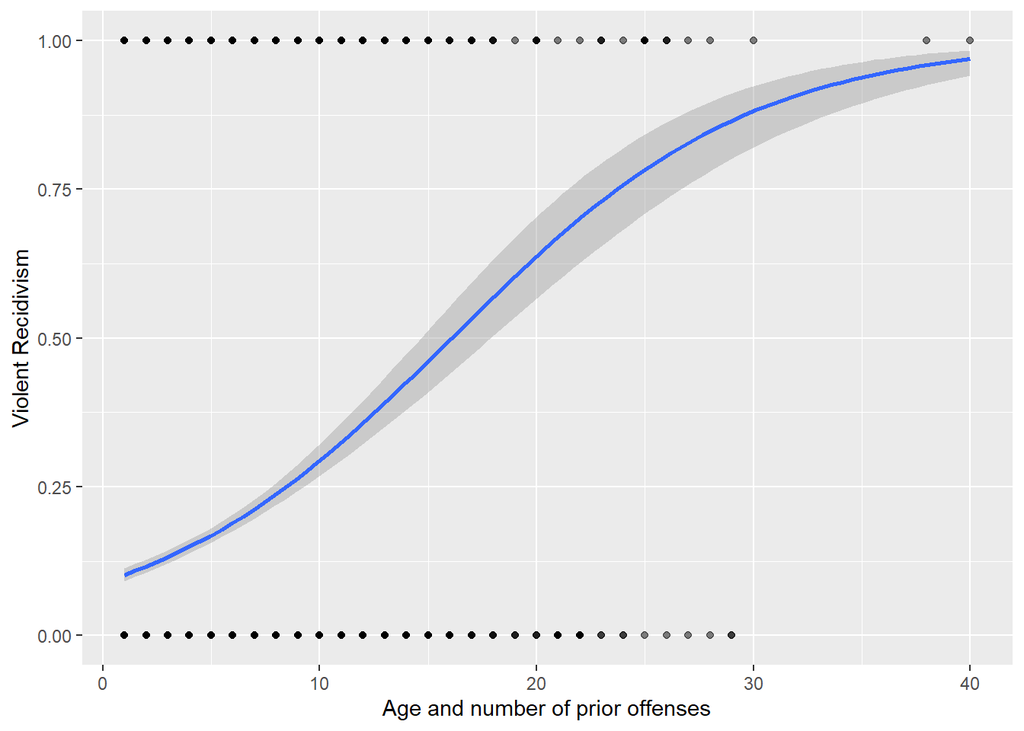

```r
# Plot model with age and priors_count
ggplot(compvio, aes(x = as.numeric(age_factor) + priors_count, y = two_year_recid)) +
  geom_point(alpha = .5) +
  stat_smooth(method = "glm", method.args = list(family = "binomial")) +
  ylab("Violent Recidivism") +
  xlab("Age and number of prior offenses")
```

```r
# create logistic regression model with `two_year_recid` as the response and `age`, `priors_count`, 'sex', and 'race' as the inputs
log.reg4 <- glm(two_year_recid ~ age_cat + priors_count + sex + race, family = "binomial", data=compvio)

# Use the `summary()` and `kable()` commands to produce a nice looking coefficients table
summary(log.reg4)
```

```
##
## Call:
## glm(formula = two_year_recid ~ age_cat + priors_count + sex +
##     race, family = "binomial", data = compvio)
##
## Deviance Residuals:
##     Min       1Q   Median       3Q      Max
## -2.1348  -0.6018  -0.4897  -0.2928   2.7514
##
## Coefficients:
##                        Estimate Std. Error z value Pr(>|z|)
## (Intercept)            -2.45432    0.13964 -17.575  < 2e-16 ***
## age_catGreater than 45 -1.06792    0.14640  -7.294 3.00e-13 ***
## age_catLess than 25     0.64935    0.10905   5.955 2.61e-09 ***
## priors_count            0.14783    0.01048  14.104  < 2e-16 ***
## sexMale                 0.63361    0.13288   4.768 1.86e-06 ***
## raceAsian              -0.38875    0.63179  -0.615  0.53835
## raceCaucasian          -0.23983    0.10507  -2.283  0.02245 *
## raceHispanic           -0.62352    0.19465  -3.203  0.00136 **
## raceNative American    -0.42723    1.09170  -0.391  0.69554
## raceOther              -0.15695    0.19971  -0.786  0.43193
## ---
## Signif. codes:  0 '***' 0.001 '**' 0.01 '*' 0.05 '.' 0.1 ' ' 1
##
## (Dispersion parameter for binomial family taken to be 1)
##
##     Null deviance: 3562.2  on 4014  degrees of freedom
## Residual deviance: 3166.4  on 4005  degrees of freedom
## AIC: 3186.4
##
## Number of Fisher Scoring iterations: 5
```

```r
kable(coef(summary(log.reg4)), digits = c(3, 3, 2, 4))
```

|  | Estimate | Std. Error | z value | Pr(>\|z\|) |
| --- | --- | --- | --- | --- |
| (Intercept) | -2.454 | 0.140 | -17.58 | 0.0000 |
| age_catGreater than 45 | -1.068 | 0.146 | -7.29 | 0.0000 |
| age_catLess than 25 | 0.649 | 0.109 | 5.95 | 0.0000 |
| priors_count | 0.148 | 0.010 | 14.10 | 0.0000 |
| sexMale | 0.634 | 0.133 | 4.77 | 0.0000 |
| raceAsian | -0.389 | 0.632 | -0.62 | 0.5383 |
| raceCaucasian | -0.240 | 0.105 | -2.28 | 0.0225 |
| raceHispanic | -0.624 | 0.195 | -3.20 | 0.0014 |
| raceNative American | -0.427 | 1.092 | -0.39 | 0.6955 |
| raceOther | -0.157 | 0.200 | -0.79 | 0.4319 |

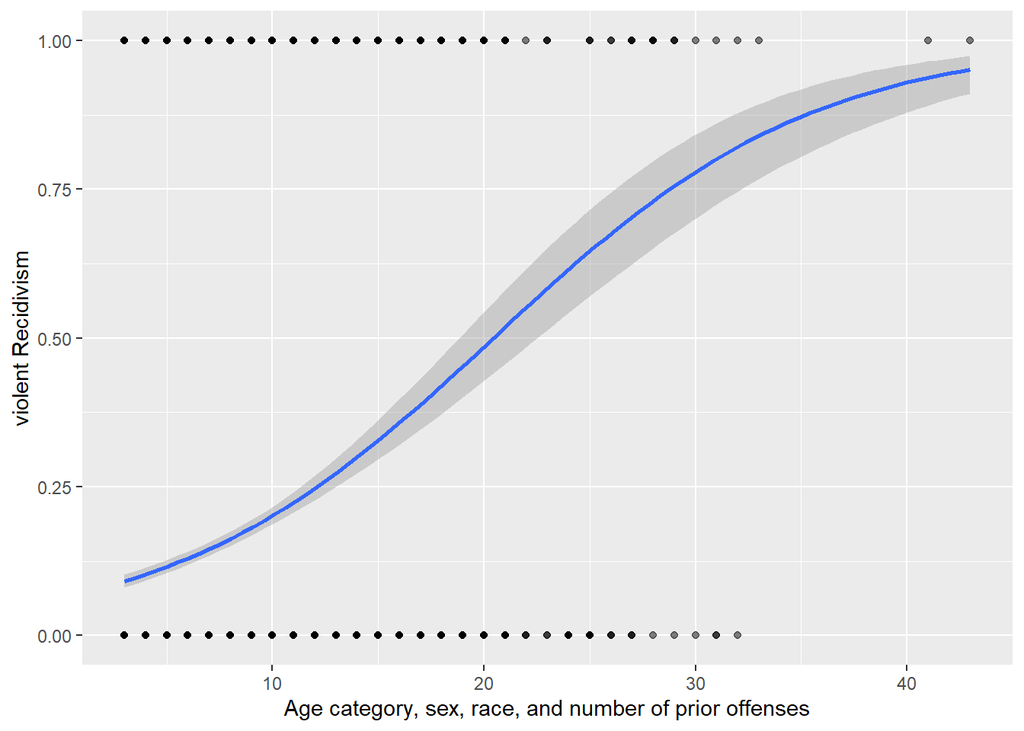

```r
compvio <- mutate(compvio, crime_factor = factor(c_charge_degree)) %>%
      mutate(age_factor = as.factor(age_cat)) %>%
      within(age_factor <- relevel(age_factor, ref = 1)) %>%
      mutate(race_factor = factor(race)) %>%
      within(race_factor <- relevel(race_factor, ref = 3)) %>%
      mutate(gender_factor = factor(sex, labels= c("Female","Male"))) %>%
      within(gender_factor <- relevel(gender_factor, ref = 2)) %>%
      mutate(score_factor = factor(score_text != "Low", labels = c("LowScore","HighScore")))

# Plot model with all inputs
ggplot(compvio, aes(x = as.numeric(age_factor) + priors_count + as.numeric(gender_factor) + as.numeric(race_factor), y = two_year_recid)) +
  geom_point(alpha = .5) +
  stat_smooth(method = "glm", method.args = list(family = "binomial")) +
  ylab("violent Recidivism") +
  xlab("Age category, sex, race, and number of prior offenses")
```

##### (c) Determine the most important predictors of recidivism

```r
# Identify the statistically significant predictors
sig.coef4 <- summary(log.reg4)$coef[summary(log.reg4)$coef[,4] <= .05, 4]
names(sig.coef4)
```

```
## [1] "(Intercept)"            "age_catGreater than 45"
## [3] "age_catLess than 25"    "priors_count"
## [5] "sexMale"                "raceCaucasian"
## [7] "raceHispanic"
```

The predictors whose coefficient estimates are statistically significant at the 0.05 level are (Intercept), age_catGreater than 45, age_catLess than 25, priors_count, sexMale, raceCaucasian, raceHispanic.